# BCB420 Assignment #1 - Data set selection, clean and scoring

Anzar Alvi

2026-02-10

## Table of contents

1. Introduction

   1.1 Background

   1.2 Dataset source and details

   1.3 Research question and hypothesis
2. Data loading, pre-processing, and normalization

   2.1 Data acquisition

   2.2 Mapping to HUGO symbols

   2.3 Data cleaning

   2.4 Exploratory data analysis and normalization
3. Differential gene expression analysis

   3.1 Model design

   3.2 Statistical testing

   3.3 Thresholds

   3.4 Volcano plot

   3.5 Heatmap of top genes
4. Dataset interpretation and documentation
5. Conclusion
6. Link to journal entry
7. References

## 1. Introduction

### 1.1 Background

Tuberculosis (TB) is a contagious bacterial disease caused by *Mycobacterium tuberculosis* which mainly impacts the lungs but can have an effect on other parts of the body too. TB is known as one of the main causes of mortality worldwide (≈1.25 million deaths and 10.8 million cases in 2023). TB infection exists along a spectrum. The most common form is Active Tuberculosis (ATB), where individuals exhibit clinical symptoms and are able to transfer the disease to other people. There is another form of TB called Latent Tuberculosis Infection (LTBI) in which the pathogen is present in the individual, but in a dormant state. The outcome of this is that those with LTBI will not exhibit symptoms and are not contagious (Luo 2025). Characterizing the differences between ATB and LTBI is critical for effective diagnosis, treatment, and disease control.

Gene expression profiling for patients with TB will allow for an understanding of the host immune response during the infection (which will further reveal molecular signatures linked to TB progression). Furthermore, identifying transcriptional differences between ATB and LTBI will help for the understanding of underlying biological processes (e.g., related to immunological or inflammatory processes) driving the shift from a latent to active disease. So, studying expression patterns is biologically meaningful for 2 key reasons: 1) it improves understanding of TB pathogenesis, and 2) it can reveal key biomarkers that distinguishes active diseases from latent infections.

### 1.2 Dataset source and details

The dataset selected for this study (GSE152218) came from the Gene Expression Omnibus (GEO) in the National Center for Biotechnology Information (NCBI). This study investigates transcriptional differences between ATB and LTBI in human samples using expression profiling by high throughput bulk RNA sequencing of whole blood cells (Illumina HiSeq 2500 (*Homo sapiens*)). The dataset was submitted on June 10th, 2020, officially published/made public on January 1st, 2021, and last updated on October 28th, 2022 by William Evan Johnson at the Division of Computational Biomedicine and Boston University. There are 2 key publications associated with this dataset: 1) Comparing tuberculosis gene signatures in malnourished individuals using the TBSignatureProfiler (Johnson et al. 2021), and 2) Malnutrition leads to increased inflammation and expression of tuberculosis risk signatures in recently exposed household contacts of pulmonary tuberculosis (VanValkenburg et al. 2022). The common aim for the studies were to identify host transcriptional signatures associated with TB progression.

Some key metadata information of this dataset (n=48) tell us that there are 23 females & 25 males, age range from 12-68, and there are 4 malnourished LTBI and 2 malnourished ATB patients.

### 1.3 Research question and hypothesis

The research question I am asking is: Which genes are differentially expressed between ATB and LTBI?

I hypothesize that ATB samples will show upregulation of genes compared to LTBI samples.

## 2. Data loading, pre-processing, and normalization

### 2.1 Data acquisition

Before acquiring any data, all required packages were installed and loaded in. The following packages were required: `BiocManager` (Morgan and Ramos 2025), `GEOquery` (Davis and Meltzer 2007), `biomaRt` (Durinck et al. 2009), `ggplot2` (Wickham 2016), `reshape2` (Wickham 2007), `DESeq2` (Love, Huber, and Anders 2014), `dplyr` (Wickham et al. 2026), `limma` (Ritchie et al. 2015), `ggrepel` (Slowikowski 2024), `ComplexHeatmap` (Gu, Eils, and Schlesner 2016), and `grid` (R Core Team 2025).

```r
# Install and load BiocManager
if (!requireNamespace("BiocManager", quietly = TRUE)) {
  install.packages(BiocManager, dependencies = TRUE)
  library("BiocManager")
} else {
  library("BiocManager")
}

# Install and load GEOquery
if (!requireNamespace("GEOquery", quietly = TRUE)) {
  BiocManager::install("GEOquery")
  library("GEOquery")
} else {
  library("GEOquery")
}

# Install and load biomaRt
if (!requireNamespace("biomaRt", quietly = TRUE)) {
  BiocManager::install("biomaRt")
  library("biomaRt")
} else {
  library("biomaRt")
}

# Install and load ggplot2
if (!requireNamespace("ggplot2", quietly = TRUE)) {
  BiocManager::install("ggplot2")
  library("ggplot2")
} else {
  library("ggplot2")
}

# Install and load reshape2
if (!requireNamespace("reshape2", quietly = TRUE)) {
  BiocManager::install("reshape2")
  library("reshape2")
} else {
  library("reshape2")
}

# Install and load DESeq2
if (!requireNamespace("DESeq2", quietly = TRUE)) {
  BiocManager::install("DESeq2")
  library("DESeq2")
} else {
  library("DESeq2")
}

# Install and load dplyr
if (!requireNamespace("dplyr", quietly = TRUE)) {
  BiocManager::install("dplyr")
  library("dplyr")
} else {
  library("dplyr")
}

# Install and load limma
if (!requireNamespace("limma", quietly = TRUE)) {
  BiocManager::install("limma")
  library("limma")
} else {
  library("limma")
}

# Install and load ggrepel
if (!requireNamespace("ggrepel", quietly = TRUE)) {
  BiocManager::install("ggrepel")
  library("ggrepel")
} else {
  library("ggrepel")
}

# Install and load ComplexHeatmap
if (!requireNamespace("ComplexHeatmap", quietly = TRUE)) {
  BiocManager::install("ComplexHeatmap")
  library("ComplexHeatmap")
} else {
  library("ComplexHeatmap")
}

# Install and load grid
if (!requireNamespace("grid", quietly = TRUE)) {
  BiocManager::install("grid")
  library("grid")
} else {
  library("grid")
}
```

Gene expression data (raw counts for bulk RNA-sequencing) for GSE152218 were obtained from GEO using the `GEOquery` R package. The series matrix file was downloaded to access both processed expression data and sample metadata. Then, phenotype information (key metadata information) for all samples was extracted. Furthermore, the supplementary files were retrieved to obtain the raw count matrix.

```r
# Retrieve the series matrix
gse_list <- getGEO("GSE152218", GSEMatrix = TRUE)
gse <- gse_list[[1]]

# Retrieve metadata for all samples
pheno <- pData(gse)

# Retreive the expression matrix
expr <- exprs(gse)

# Retrieve supplementary data (this is where the raw counts are)
supp <- getGEOSuppFiles("GSE152218",
                        makeDirectory = FALSE,
                        baseDir = tempdir()
)

supp_files <- rownames(supp) # This is the path for the supplementary data (it's a gz file)

# Read in raw counts
dat <- read.delim(
  gzfile(supp_files[1]),
  stringsAsFactors = FALSE
)

colnames(dat)[colnames(dat) == "X"] <- "ensembl_gene_id" # Rename

# There should be 49 columns (1 named "ensembl_gene_id" and 48 patient id's)
```

### 2.2 Mapping to HUGO symbols

The gene expression dataset originally contained Ensembl gene identifiers. I converted these to HUGO gene symbols approved by the HGNC (as per assignment instructions). First, version suffixes (e.g., ENSG0000001234.5) were removed from Ensembl IDs to ensure mapping was accurate.

Gene ID conversion (from Ensembl to HUGO) was done using the `biomaRt` package in R, querying the Ensembl BioMart database (human dataset: *hsapiens_gene_ensembl*, version 115). Then, the cleaned Ensembl gene IDs (without suffixes) were submitted to BioMart using the `getBM()` function in order to retrieve HUGO symbols.

```r
# List avaialble BioMart databases
# listMarts()

# Use ensembl
ensembl <- useEnsembl(
  biomart = "genes",
  dataset = "hsapiens_gene_ensembl",
  version = 115
)

# List the datasets and select human
datasets <- listDatasets(ensembl)
human <- datasets[grep(datasets$dataset, pattern = "hsapiens"), ]

# Identify correct filter
all_filters <- listFilters(ensembl)
# all_filters[grep(all_filters$name, pattern = "ensembl_gene"), ]

# Identify the correct attributes
all_attr <- listAttributes(ensembl)
# all_attr[1:10, ]

# Search for hgnc
# searchAttributes(ensembl, "hgnc")

# Strip the version suffixes
strip_ensembl_version <- function(x) sub("\\..*$", "", x)
ids <- dat$ensembl_gene_id
ids_clean <- strip_ensembl_version(ids)

# Run query with getBM() to get hgnc id's
map <- getBM(
  attributes = c("ensembl_gene_id", "hgnc_symbol"),
  filters = "ensembl_gene_id",
  values = ids_clean,
  mart = ensembl
)
```

### 2.3 Data cleaning

After mapping Ensembl IDs to HUGO symbols, I cleaned my data to ensure each row represents a single gene (while keeping the dataset as complete as possible). As I was doing identifier mapping, I identified 3 possible issues which could have occurred and how to deal with each of them:

1. One Ensembl ID maps to multiple HUGO symbols

   This can occur because of either non-unique fragments, weak annotations or overlapping transcripts. Fortunately, I did not face this issue.
2. Multiple Ensembl IDs map to one HUGO symbol

   This can occur due to alternate annotations, or something related. To ensure that our final matrix has one gene per row, I kept the first occurrence of the HUGO symbol and removed the duplicates. This prevented the same gene being counted multiple times (leading to inaccurate differential expression results).
3. No HUGO symbol was available (empty mapping)

   Instead of removing such genes, I retained them, but used their Ensembl gene ID as their identifier. The reason is because it would be wrong to make the assumption that genes without an HUGO mapping are irrelevant in differential expression analysis. So, in order to avoid discarding potentially relevant features (even if they lack an HUGO symbol due to updated loci, un-characterized loci, or something related), I preserved a unique identifier for the gene for differential expression analysis.

Finally, low-count genes were also filtered out (I ensured that each gene has a total read count >10 across all samples) (Paton et al. 2024). This is because genes with very low counts tend to produce inaccurate dispersion estimates, contribute to noise, and increase the multiple-testing burden in differential expression analysis.

```r
# Deduplicate mapping: keep first valid HGNC per Ensembl ID (Case 1)
# We didn't face any issue here, but the code is still present and run
map_deduplicated <- map %>%
  group_by(ensembl_gene_id) %>%
  summarize(
    hgnc_symbol = {
      x <- hgnc_symbol[hgnc_symbol != ""]
      if (length(x) == 0) NA_character_ else x[1]
    },
    .groups = "drop"
  )

# Merge mapping back into dat
dat$ensembl_gene_id <- ids_clean
dat$hgnc_symbol <- map_deduplicated$hgnc_symbol[match(dat$ensembl_gene_id, map_deduplicated$ensembl_gene_id)]

# Create final gene identifier:
# - use HGNC when available
# - otherwise keep Ensembl ID (Case 3)
dat$final_id <- ifelse(is.na(dat$hgnc_symbol) | dat$hgnc_symbol == "",
                       dat$ensembl_gene_id,
                       dat$hgnc_symbol)

# Enforce one gene per row (Case 2):
# If multiple rows map to the same HGNC symbol, keep the first occurrence
dat <- dat[!duplicated(dat$final_id), ]

# Set rownames to final_id (mix of HGNC + Ensembl for unmapped)
rownames(dat) <- dat$final_id

# Remove identifier columns from count matrix
clean_dat <- dat[, !(colnames(dat) %in% c("ensembl_gene_id", "hgnc_symbol", "final_id"))]

# Counts matrix
count_mat <- as.matrix(clean_dat)
storage.mode(count_mat) <- "integer"

# Low count filtering (total count > 10 across all samples)
keep <- rowSums(count_mat) > 10
count_mat <- count_mat[keep, ]

# Show table 1
head(data.frame(count_mat), 10)
```

|  | X102.00042.B | X102.00088.B | X102.00129.B0 | X102.00131.B | X102.00171.B | X102.00188.B | X102.00216.B | X102.00217.B | X102.00227.B | X102.00240.B | X102.00241.B | X102.00246.B | X102.00247.B | X102.00261.B | X102.00265.B0 | X102.00275.B | X102.00277.B | X102.00290.B | X102.00291.B | X102.00298.B | X102.00303.A | X102.00304.B | X102.00308.A0 | X102.00308.B0 | X102.00310.B | X102.00311.A | X102.00315.A | X102.00323.B | X102.00332.A | … |
| --- | --- | --- | --- | --- | --- | --- | --- | --- | --- | --- | --- | --- | --- | --- | --- | --- | --- | --- | --- | --- | --- | --- | --- | --- | --- | --- | --- | --- | --- | --- |
| DDX11L1 | 4 | 4 | 3 | 4 | 1 | 0 | 1 | 1 | 3 | 4 | 9 | 0 | 0 | 0 | 1 | 0 | 0 | 1 | 3 | 7 | 1 | 5 | 1 | 0 | 0 | 4 | 0 | 1 | 2 | … |
| WASH7P | 392 | 237 | 247 | 259 | 261 | 116 | 254 | 190 | 121 | 123 | 194 | 271 | 114 | 139 | 317 | 127 | 190 | 72 | 113 | 208 | 79 | 223 | 132 | 149 | 191 | 222 | 191 | 222 | 122 | … |
| MIR6859-1 | 49 | 35 | 26 | 37 | 36 | 17 | 27 | 21 | 11 | 19 | 32 | 31 | 13 | 28 | 28 | 17 | 7 | 10 | 5 | 29 | 15 | 36 | 19 | 42 | 28 | 24 | 20 | 16 | 14 | … |
| FAM138A | 0 | 0 | 0 | 0 | 0 | 0 | 0 | 0 | 0 | 0 | 0 | 0 | 0 | 0 | 0 | 0 | 0 | 0 | 0 | 0 | 0 | 0 | 0 | 0 | 0 | 0 | 0 | 0 | 0 | … |
| OR4F5 | 0 | 0 | 0 | 0 | 0 | 0 | 0 | 0 | 0 | 0 | 0 | 0 | 0 | 0 | 0 | 0 | 0 | 0 | 0 | 0 | 0 | 0 | 0 | 0 | 0 | 0 | 0 | 0 | 1 | … |
| ENSG00000238009 | 21 | 0 | 8 | 16 | 7 | 5 | 4 | 6 | 3 | 13 | 7 | 12 | 3 | 13 | 9 | 1 | 2 | 1 | 6 | 7 | 6 | 4 | 2 | 3 | 4 | 11 | 19 | 11 | 11 | … |
| CICP27 | 279 | 19 | 85 | 100 | 72 | 28 | 56 | 25 | 20 | 126 | 55 | 26 | 28 | 143 | 37 | 29 | 32 | 19 | 23 | 33 | 59 | 35 | 112 | 40 | 24 | 60 | 112 | 39 | 54 | … |
| ENSG00000268903 | 6157 | 899 | 2586 | 2586 | 1835 | 1246 | 2070 | 1238 | 846 | 2626 | 1341 | 955 | 745 | 3277 | 2149 | 881 | 1013 | 870 | 1285 | 1331 | 2193 | 1742 | 3523 | 2451 | 1436 | 1851 | 3068 | 1836 | 2012 | … |
| ENSG00000269981 | 5813 | 648 | 1909 | 2283 | 1463 | 915 | 1447 | 1076 | 741 | 2254 | 1308 | 828 | 592 | 3249 | 1455 | 577 | 717 | 629 | 1348 | 1160 | 1771 | 1659 | 2610 | 1688 | 1137 | 1416 | 2573 | 1566 | 2277 | … |
| ENSG00000239906 | 83 | 13 | 18 | 22 | 18 | 16 | 57 | 19 | 15 | 40 | 12 | 15 | 19 | 50 | 33 | 10 | 12 | 4 | 27 | 15 | 29 | 24 | 43 | 30 | 29 | 14 | 45 | 9 | 41 | … |

```r
# Collecting metadata
samp <- colnames(count_mat)

group <- ifelse(grepl("A0$|A$", samp), "activeTB",
          ifelse(grepl("B0$|B$", samp), "LTBI", NA))
group <- factor(group, levels = c("LTBI", "activeTB"))

meta <- data.frame(row.names = samp, group = group)
```

**Table 1. Preview of the cleaned RNA-seq count matrix.** The table shows the first 10 rows of the processed gene expression count matrix (pre-normalization) after mapping HUGO symbols and cleaning data. Each row is a unique gene and each column is a unique sample. Some Ensembl gene IDs are present (for identifiers whch had an empty HUGO mapping). Entries are raw read counts.

### 2.4 Exploratory data analysis and normalization

In order to assess overall data quality and prepare the counts matrix for differential expression analysis, several exploratory analyses were performed, along with normalization. These include: evaluating library sizes, expression distributions pre- and post-normalization, sample clustering using a multidimensional scaling (MDS) plot, and gene-wise dispersion estimates. By performing all these steps, I was able to identify technical variation and confirm that the dataset I am working with is suitable for the chosen statistical model.

#### 2.4.1 Library size distribution

Library size (i.e., the total number of counts per sample) was examined in order to examine the consistency across samples.

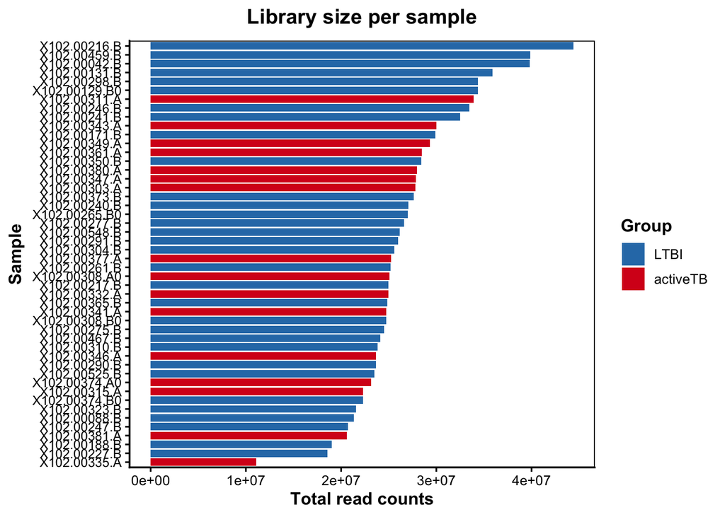

```r
# Library sizes
lib_size <- colSums(count_mat)

# Build plotting df in same order as matrix
lib_df <- data.frame(
  sample = colnames(count_mat),
  library_size = as.numeric(lib_size),
  group = meta$group
)

# Order by library size (small -> large)
lib_df <- lib_df[order(lib_df$library_size), ]
lib_df$sample <- factor(lib_df$sample, levels = lib_df$sample)

ggplot(lib_df, aes(x = sample, y = library_size, fill = group)) +
  geom_col(width = 0.85) +
  coord_flip() +
  labs(
    title = expression(bold("Library size per sample")),
    x = expression(bold("Sample")),
    y = expression(bold("Total read counts")),
    fill = "Group"
  ) +
  scale_fill_manual(values = c("LTBI" = "#2C7BB6", "activeTB" = "#D7191C")) +
  theme_classic(base_size = 12) +
  theme(
    plot.title = element_text(hjust = 0.5),
    axis.text.y = element_text(size = 9),
    legend.title = element_text(face = "bold"),
    panel.border = element_rect(colour = "black", fill = NA, linewidth = 0.6)
  )
```

**Figure 1. Library size per sample.** Bar plot showing total number of counts (library size) for each sample after pre-processing and gene filtering, but before normalization. Samples are labeled by condition as either activeTB or LTBI, and ordered by increasing library size. The x-axis represents total read counts, and the y-axis represents individual samples (n=48).

*Figure 1* clearly shows variation in total read counts across samples. This is strong justification for normalizing the count data to ensure expression values that are comparable across samples.

#### 2.4.2 Expression distribution before normalization

A boxplot of log-transformed raw counts was generated in order to show how expression data is distributed across samples, before normalization.

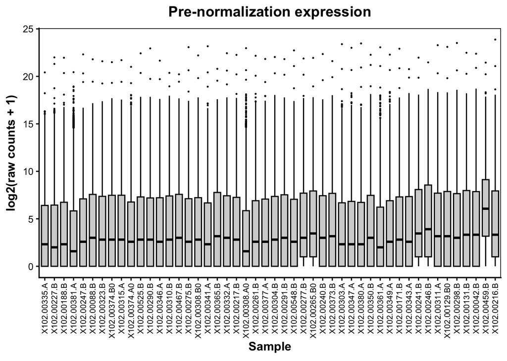

```r
# Use the same ordering as the barplot (increasing library size)
lib_order <- names(sort(colSums(count_mat)))     # original colnames, ordered

pre_df <- as.data.frame(log2(count_mat + 1))
pre_df$gene <- rownames(pre_df)

pre_long <- melt(pre_df, id.vars = "gene",
                 variable.name = "sample",
                 value.name = "expression")

# Clean sample IDs + enforce barplot order
pre_long$sample <- factor(pre_long$sample, levels = lib_order)

ggplot(pre_long, aes(x = sample, y = expression)) +
  geom_boxplot(width = 0.7, outlier.size = 0.25,
               fill = "lightgrey", colour = "black") +
  labs(
    title = expression(bold("Pre-normalization expression")),
    x = expression(bold("Sample")),
    y = expression(bold("log2(raw counts + 1)"))
  ) +
  theme_classic(base_size = 12) +
  theme(
    plot.title = element_text(hjust = 0.5),
    axis.text.x = element_text(angle = 90, vjust = 0.5, hjust = 1, size = 8),
    panel.border = element_rect(colour = "black", fill = NA, linewidth = 0.6)
  )
```

**Figure 2. Pre-normalization expression distribution across samples.** Boxplots showing how gene expression is distributed across samples before normalization, plotted as log2(raw counts + 1).

#### 2.4.3 Normalization and variance stabilization

Normalization of the data was first done using the `DESeq2` R package using the “median-of-ratios” method. This is a robust RNA-seq normalization method in which a scaling factor (size factor) for every sample is computed by dividing counts by a pseudo-reference (geometric mean), then taking the median of these ratios. After this step that corrected for differences in sequencing depth and RNA composition between samples, Variance Stabilizing Transformation (VST) was applied to reduce the dependence that variance has on mean expression. The result is data that is approximately homoscedastic (very well suited for visualization and clustering).

```r
# Build dds
dds <- DESeqDataSetFromMatrix(countData = count_mat, colData = meta, design = ~ group)

# Normalization
dds <- DESeq(dds)

# VST transform
vsd <- vst(dds, blind = TRUE)
vsd_mat <- assay(vsd)
```

#### 2.4.2 Expression distribution after normalization

After normalizing with the median-of-ratios method in `DESeq2` and VST, a boxplot of the counts was generated in order to show how expression data is distributed across samples, post-normalization.

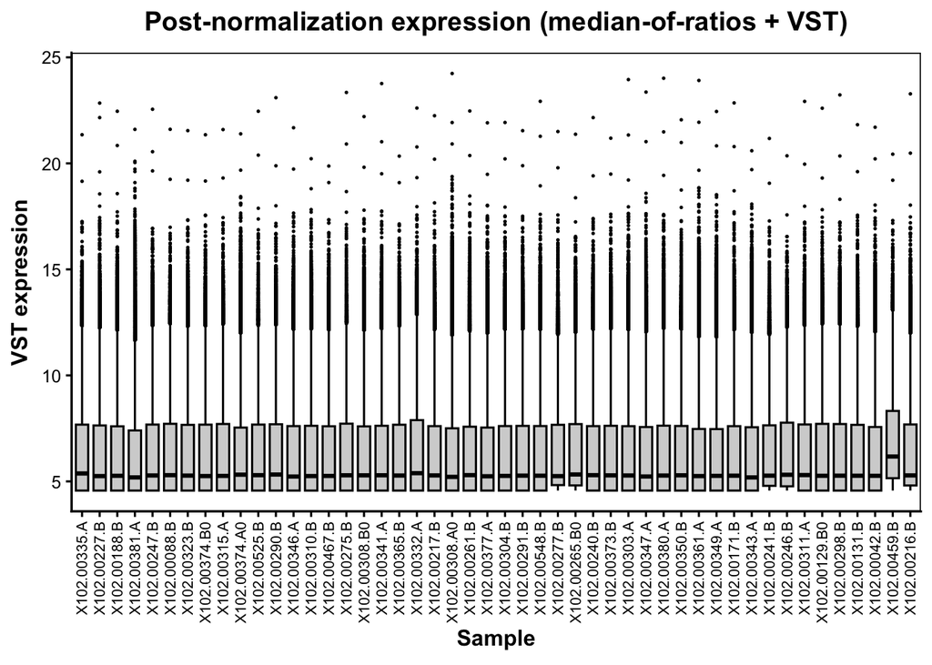

```r
# Same ordering as barplot (increasing library size)
lib_order <- names(sort(colSums(count_mat)))
post_df <- as.data.frame(vsd_mat)
post_df$gene <- rownames(post_df)

post_long <- melt(post_df, id.vars = "gene",
                  variable.name = "sample",
                  value.name = "expression")

# Clean sample IDs + enforce same order
post_long$sample <- factor(post_long$sample, levels = lib_order)

# Plot the boxplot
ggplot(post_long, aes(x = sample, y = expression)) +
  geom_boxplot(width = 0.7, outlier.size = 0.25,
               fill = "lightgrey", colour = "black") +
  labs(
    title = expression(bold("Post-normalization expression (median-of-ratios + VST)")),
    x = expression(bold("Sample")),
    y = expression(bold("VST expression"))
  ) +
  theme_classic(base_size = 12) +
  theme(
    plot.title = element_text(hjust = 0.5),
    axis.text.x = element_text(angle = 90, vjust = 0.5, hjust = 1, size = 8),
    panel.border = element_rect(colour = "black", fill = NA, linewidth = 0.6)
  )
```

**Figure 3. Post-normalization expression distributions across samples.** Boxplots showing each sample’s distribution of variance-stabilized expression values (VST) after normalization and transformation.

#### 2.4.3 Multidimensional scaling (MDS)

MDS was performed in order to see the similarity between samples (based on gene expression). The plot in *Figure 4* shows that samples with similar transcriptional profiles will cluster together (in a low dimensional space).

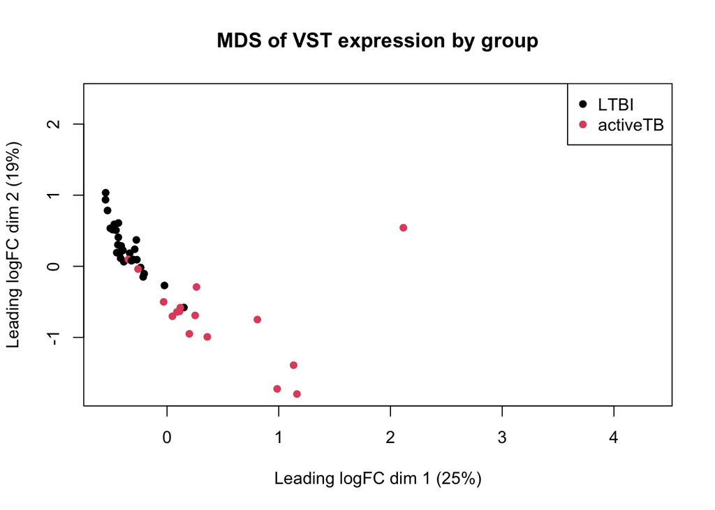

```r
# Plot the MDS plot
plotMDS(vsd_mat,
        col = as.numeric(meta$group),
        pch = 16,
        main = expression(bold("MDS of VST expression by group"))) # Bolded title

# Legend customization for MDS plot
legend("topright",
       legend = levels(meta$group),
       col = 1:length(levels(meta$group)),
       pch = 16,
       bty = "o")
```

**Figure 4. Multidimensional scaling (MDS) plot of samples based on VST expression.** MDS plot generated from variance-stabilized (VST) expression values. All the samples are projected onto the first 2 dimensions (which is dervied from leading log fold-change, logFC, variation). Each point is an individual sample and is coloured by group (black dot is LTBI and pink dot is activeTB).

**Testing for potential outlier**

The MDS plot shows one sample quite far away from the other samples at around (2.1, 0.5) in *Figure 4*.

```r
# Get MDS coordinates without plotting
mds <- plotMDS(vsd_mat, plot = FALSE)

# Euclidean distance from the centroid in MDS space
coords <- data.frame(sample = colnames(vsd_mat),
                     dim1 = mds$x, dim2 = mds$y)

coords$dist <- sqrt((coords$dim1 - mean(coords$dim1))^2 +
                    (coords$dim2 - mean(coords$dim2))^2)

# Print the most extreme sample (far-right point)
# coords[order(-coords$dist), ][1, ]

# Compare library size of that sample vs others
outlier_sample <- coords$sample[which.max(coords$dist)]
lib_size <- colSums(count_mat)

# summary(lib_size)
# lib_size[outlier_sample]

# Check how extreme it is (z-score)
z <- (lib_size - mean(lib_size)) / sd(lib_size)
# z[outlier_sample]
```

#### 2.4.4 Dispersion and biological coefficient of variation (BCV)

Gene-wise dispersion estimates from DESeq2 as a function of mean normalized expression was computed using the `plotDispEsts()` function from the `DESeq2` R package.

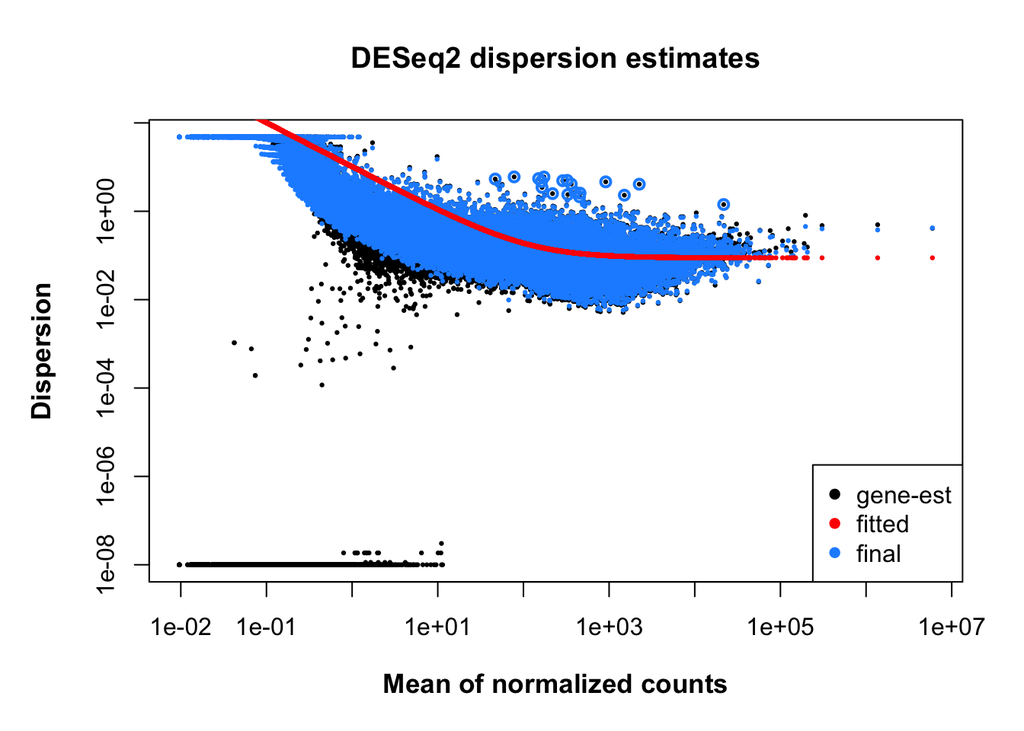

```r
# Save current par settings so you don't permanently change plots
op <- par(no.readonly = TRUE)

par(
  mar = c(5, 5, 4, 2) + 0.1,  # Margins: bottom, left, top, right
  cex.lab = 1.1,
  cex.main = 1.2,
  bty = "o"                   # Box around plotting region
)

plotDispEsts(
  dds,
  main = expression(bold("DESeq2 dispersion estimates")),
  xlab = expression(bold("Mean of normalized counts")),
  ylab = expression(bold("Dispersion"))
)
```

```r
par(op)
```

**Figure 5. DESeq2 dispersion estimates as a function of mean normalized gene expression.** Dispersion plot produced by `plotDispEsts()`. The plot shows gene-wise dispersion estimates (black points) versus the mean of normalized counts (x-axis, log-scaled). The red line shows the fitted dispersion trend, and the blue line shows the final dispersion values used by DESeq2. The y-axis is showing dispersion (log-scaled).

*Figure 5* shows a decrease in dispersion as mean expression increases. This is as expected as lower count genes typically have more variability. Hence, the plot supports a negative binomial model for differential expression.

## 3. Differential gene expression analysis

### 3.1 Model design

Differential gene expression analysis was performed using the `DESeq()` function in the `DESeq2` R package which models the count data using a negative binomial distribution. Experimental design consisted of a single factor (`group`) which represented either activeTB or LTBI (where LTBI was used as the reference). This setup enabled comparisons to be made between activeTB and LTBI using log2 fold-change estimates.

The pipeline used by `DESeq2` includes size factor estimates for normalization, estimates for dispersion, and gene-wise generalized linear models when fitting.

### 3.2 Statistical testing

`DESeq2` uses the Wald test for testing statistical significance. For each gene, the model tested if the expression between activeTB and LTBI patients were significantly different (p ≤ 0.05).

For the correction of multiple hypothesis testing, adjusted p-values were computed using the Benjamini-Hochberg false discovery rate (FDR) method (built into `DESeq2`). There were genes with “NA” for their adjusted p-values, and they were excluded for any downstream analyses.

Differential expression statistics are summarized in *Table 2*.

```r
# Extract results for activeTB vs LTBI
res <- results(dds, contrast = c("group", "activeTB", "LTBI"))

# Remove genes with NA adjusted p-values (often independent filtering)
res <- res[!is.na(res$padj), ]

# Convert results to dataframe
res_df <- as.data.frame(res)

# Add gene column
res_df$gene <- rownames(res_df)

# Keep only the important columns
table2 <- res_df[, c("gene", "log2FoldChange", "pvalue", "padj")]

# Order by adjusted p-value
table2 <- table2[order(table2$padj), ]

# Add direction column
table2$direction <- ifelse(table2$log2FoldChange > 0,
                           "upregulated (activeTB)",
                           "downregulated (activeTB)")

# Show top 10 genes with lowest padj values
head(table2, 10)
```

|  | gene | log2FoldChange | pvalue | padj | direction |
| --- | --- | --- | --- | --- | --- |
| HIP1R | HIP1R | -1.2335869 | 5.097198e-28 | 1.414116e-23 | downregulated (activeTB) |
| TTC9 | TTC9 | -1.3088697 | 5.628440e-24 | 7.807491e-20 | downregulated (activeTB) |
| SMARCD3 | SMARCD3 | 2.2850881 | 1.240860e-22 | 1.147506e-18 | upregulated (activeTB) |
| OSBPL10 | OSBPL10 | -1.8426716 | 6.121237e-22 | 4.245537e-18 | downregulated (activeTB) |
| CELSR1 | CELSR1 | -1.6724166 | 1.082215e-21 | 6.004779e-18 | downregulated (activeTB) |
| NXPH4 | NXPH4 | -2.9127776 | 2.393029e-21 | 1.106497e-17 | downregulated (activeTB) |
| BCL7A | BCL7A | -1.5869315 | 7.470104e-21 | 2.960616e-17 | downregulated (activeTB) |
| CD33 | CD33 | 0.8706793 | 1.869673e-20 | 6.483793e-17 | upregulated (activeTB) |
| NPC2 | NPC2 | 1.1873134 | 3.393106e-20 | 9.413494e-17 | upregulated (activeTB) |
| DUSP3 | DUSP3 | 1.2254234 | 3.148031e-20 | 9.413494e-17 | upregulated (activeTB) |

### 3.3 Thresholds

For identifying biologically meaningful differential expression, the following thresholds were set: false discovery rate (FDR) < 0.05 and absolute log2 fold-change > 1.

So, if a gene meets both criteria, they were considered to be significantly differentially expressed. Genes with a positive log2 fold-change value were up-regulated in activeTB and those with a negative log2 fold-change value were down-regulated in activeTB.

```r
# Thresholds
alpha <- 0.05 # FDR cutoff
lfc_cutoff <- 1 # |log2FC| cutoff

df <- as.data.frame(res)

df$significance <- "Not Significant"
df$significance[df$padj < alpha & df$log2FoldChange > lfc_cutoff] <- "Upregulated"
df$significance[df$padj < alpha & df$log2FoldChange < -lfc_cutoff] <- "Downregulated"
```

### 3.4 Volcano plot

For visualizing genes with significant differential expression between activeTB and LTBI samples, a volcano plot was used (*Figure 6*). The plot is very useful in identifying genes with strong differential expression between activeTB and LTBI, and more specifically, which genes specifically show increased expression in either activeTB or LTBI samples.

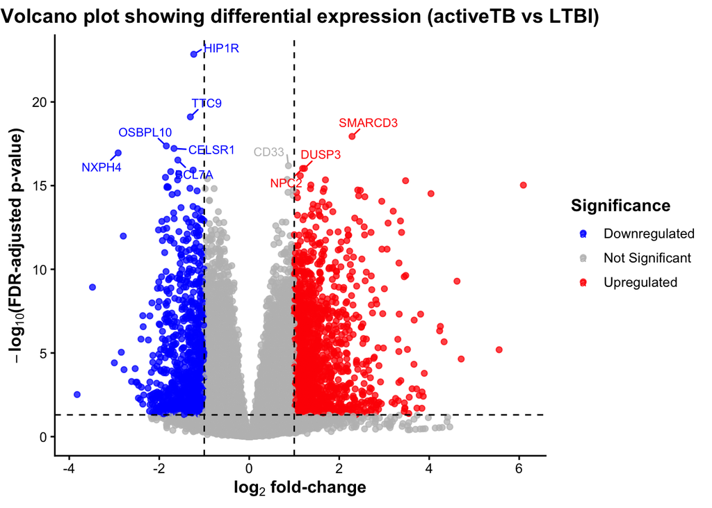

```r
# Select top genes to label (by adjusted p-value)
top <- df[order(df$padj), ][1:10, ]
top$gene <- rownames(top)

# Plot
ggplot(df, aes(x = log2FoldChange, y = -log10(padj), color = significance)) +
  geom_point(alpha = 0.75, size = 1.6) +
  geom_vline(xintercept = c(-1, 1), linetype = "dashed", linewidth = 0.5) +
  geom_hline(yintercept = -log10(0.05), linetype = "dashed", linewidth = 0.5) +
  geom_text_repel(
    data = top,
    aes(label = gene),
    size = 3,
    max.overlaps = Inf,
    box.padding = 0.4,
    point.padding = 0.2,
    min.segment.length = 0
  ) +
  scale_color_manual(values = c(
    "Upregulated" = "red",
    "Downregulated" = "blue",
    "Not Significant" = "grey"
  )) +
  labs(
    title = "Volcano plot showing differential expression (activeTB vs LTBI)",
    x = expression(bold(log[2] * " fold-change")),
    y = expression(bold(-log[10] * "(FDR-adjusted p-value)")),
    color = "Significance"
  ) +
  theme_classic(base_size = 12) +
  theme(
    plot.title = element_text(face = "bold", hjust = 0.5, size = 14),
    axis.title = element_text(face = "bold"),
    axis.text = element_text(color = "black"),
    legend.title = element_text(face = "bold"),
    legend.position = "right"
  )
```

**Figure 6. Volcano plot of differential gene expression between activeTB and LTBI.** The points in the volcano plot represent unique genes plotted by log2 fold-change (activeTB vs. LTBI) (x-axis) and significance (-log10(adjusted p value)) (y-axis). Genes which meet thresholds (FDR < 0.05 and |log2FC| > 1) are coloured either red (up-regulation in activeTB samples), blue (down-regulation in activeTB samples), or grey (genes which are not significant). The dashed horizontal line shows the FDR significance threshold, and the dashed vertical line shows the fold-change cutoff. Labeled points are the top 10 most significant genes that are differentially expressed.

### 3.5 Heatmap of top genes

In order to visualize the global transcriptional differences between activeTB and LTBI samples, a heatmap was generated using the top 100 genes (ranked by adjusted p-value). Furthermore, to highlight relative expression patterns across samples, VST values were row-scaled (z-score).

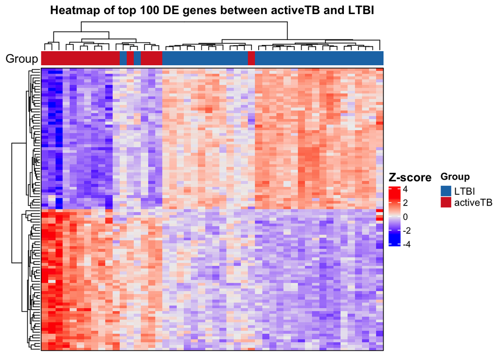

```r
# Getting normalized counts
norm_counts <- counts(dds, normalized = TRUE)
norm_counts <- as.matrix(norm_counts)

# Use DESeq2 results
res_to_rank <- res

# Set data frame
res_df <- as.data.frame(res_to_rank)

# Get top 100 genes by lowest padj
top100_genes <- rownames(res_df)[order(res_df$padj)][1:100]

# subset normalized counts
top_norm_counts <- norm_counts[top100_genes, , drop = FALSE]

# VST
vst_mat <- assay(vsd)
top_vst <- vst_mat[top100_genes, , drop = FALSE]

# Standardize each gene (row) to see relative expression across samples, not absolute counts
top_vst_z <- t(scale(t(top_vst)))
top_vst_z[is.na(top_vst_z)] <- 0

# Heatmap annotations
group_cols <- c("LTBI" = "#1f77b4", "activeTB" = "#d62728")

ha <- HeatmapAnnotation(
  Group = meta$group,
  col = list(Group = group_cols),
  annotation_name_side = "left"
)

# Draw the heatmap
basic_heatmap <- Heatmap(
  top_vst_z,
  name = "Z-score",
  top_annotation = ha,
  show_row_names = FALSE, # Remove gene labels
  show_column_names = FALSE,# Remove sample labels

  # Clustering
  cluster_columns = TRUE,
  cluster_rows = TRUE,

  # Bolded title
  column_title = "Heatmap of top 100 DE genes between activeTB and LTBI",
  column_title_gp = gpar(fontface = "bold", fontsize = 12),

  # Clean legend
  heatmap_legend_param = list(
    title_gp = gpar(fontface = "bold"),
    labels_gp = gpar(fontsize = 9)
  ),

  border = TRUE
)

# Draw heatmap
draw(basic_heatmap, heatmap_legend_side = "right", annotation_legend_side = "right")
```

**Figure 7. Heatmap of top 100 differentially expressed genes between activeTB and LTBI.** Heamtap showing variance-stabilized expression values (VST) for the top 100 genes (ordered with respect to adjusted p-value). The VST values were standardized by gene (row z-score) to emphasize expression differences across samples. Each column is a unique sample, and each row is a unique gene. Samples are labeled as either activeTB or LTBI in the “Group” row. Hierarchical clustering on both the x- and y-axis is enabled, revealing distinct transcriptional and similar differential expression patterns for the top 100 genes for both groups.

*Figure 7* demonstrates that samples clearly cluster according to their group (LTBI or activeTB). Although 2 LTBI patients clustered with the activeTB group and 1 activeTB patient clustered with the LTBI group, majority of the patients were in the right group. So, it can be concluded that LTBI and activeTB samples have distinct transcriptional profiles.

## 4. Dataset interpretation and documentation

Why is the dataset of interest to you?

From a young age I knew that the severity of tuberculosis (TB) for an individual lived on a spectrum. However, I have only now formally learned the main classifications of TB: active tuberculosis (ATB) and laent tuberculosis infection (LTBI) after exploring my dataset of interest.

The dataset (GSE152218) compares Indian individuals with ATB and LTBI. This is of interest to me because in Pakistan, my home country, TB is extremely prevalent with the 5th highest rate in the world (Ullah et al. 2024). I personally know many people, some friends and family, who have had to suffer with this horrible illness (both ATB and LTBI).

This motivates me to have a better understanding of the disease to hopefully assist in the development of personalized treatments for ATB. For example, if I’m able to understand which genes are up-regulated in ATB vs LTBI, I may be able to suggest potential drug targets, or even identify biomarkers for treatment monitoring.

What are the control and test conditions of the dataset?

The control conditions I am using in the dataset are LTBI patients. The test conditions I am using in the dataset are ATB patients.

**This information comes from section *1.2 Dataset source and details*.**

How many samples are in each of the conditions of your dataset?

There are 32 LTBI patients (control) and 16 ATB patients (test).

Were there expression values that were not unique for specific genes? How did you handle these?

Yes. There were non-unique mappings when doing identifier mapping. There were 2 cases:

1. One Ensembl ID mapped to multiple HUGO symbols

   This was not prevalent in my dataset, but the code handled it anyways by de-duplicating mapping after running `getBM()` for identifier mapping.
2. Multiple Ensembl IDs mapped to the same HUGO symbol

   In order to ensure each row was a unique gene, I kept the first occurrence of the Ensembl ID and removed other duplicates. This prevented the same gene from being counted many times during differential expression analysis.

Handling these 2 cases ensured that the final genes x samples count matrix contained unique genes.

**This information comes from section *2.3 Data cleaning*.**

Were there expression values that could not be mapped to current HUGO symbols?

Some Ensembl gene IDs did not map to HUGO symbols (likely due to poor annotations or updated loci). Instead of removing these rows, I kept them and used their Ensembl ID as the unique identifier. This was because if the un-annotated gene was potentially important (i.e., showed significant differential expression), it was not discarded.

Therefore, all genes were preserved unless they were removed by low-count filtering.

**This information comes from section *2.3 Data cleaning*.**

Were there any outliers in your dataset? How were they handled in the originating paper? How many outliers were removed?

The MDS plot showed one sample that was far away from the main cluster, but I did not immediately classify this sample as an outlier.

In summary, since I did not detect any technical issue, I kept the sample. Variation was reported as true biological variation.

**This information comes from section *2.4.3 Multidimensional scaling (MDS)*.**

How did you handle replicates?

The dataset contained human patient samples in which each sample was a unique individual. Therefore, there were no replicates in that sense.

That being said, we had multiple biological replicates (so multiple independent individuals belonging to a particular condition, either activeTB or LTBI).

The way I handled the biological replicate was by treating each patient as an independent sample within their respective group. `DESeq2` is specifically designed for this setup. The package will estimate dispersion using “within-group variability across biological replicates”.

This is the correct approach as any other method (e.g., averaging patients) would lead to the loss of true biological variability.

What is the final coverage of your dataset?

The final dataset contained 29,078 genes across 48 samples after pre-processing and filtering. This is the transcriptional coverage used for analysis.

I also computed the average library size, 26,836,006, across all 48 samples by running `mean(lib_df$library_size)`. `lib_df` was created in section *2.4.1 Library size distribution* when making the barplot showing library size per sample.

## 5. Conclusion

In this study, I successfully loaded and processed the GSE152218 RNA-seq dataset for differential gene expression analysis between ATB and LTBI samples. Ensembl gene IDs were translated to unique HUGO gene symbols, low-count genes were removed, and counts were normalized using `DESeq2`’s median-of-ratios method along with variance stabilizing transformation (VST). Exploratory analysis suggested that samples were able to be compared against each other. Finally, differential gene expression analysis suggested different transcriptional profiles between LTBI and ATB samples (as hypothesized).

## 6. Link to journal entry

The link is here: https://github.com/bcb420-2026/Anzar_Alvi/wiki/A1

## 7. References

Davis, Sean, and Paul Meltzer. 2007. “GEOquery: A Bridge Between the Gene Expression Omnibus (GEO) and BioConductor.” *Bioinformatics* 14: 1846–47. https://doi.org/10.1093/bioinformatics/btm254.

Durinck, Steffen, Paul T. Spellman, Ewan Birney, and Wolfgang Huber. 2009. “Mapping Identifiers for the Integration of Genomic Datasets with the r/Bioconductor Package biomaRt.” *Nature Protocols* 4: 1184–91.

Filzmoser, Peter, Ricardo Maronna, and Mark Werner. 2008. “Outlier Identification in High Dimensions.” *Computational Statistics & Data Analysis* 52 (3): 1694–1711. https://doi.org/10.1016/j.csda.2007.05.018.

Gu, Zuguang, Roland Eils, and Matthias Schlesner. 2016. “Complex Heatmaps Reveal Patterns and Correlations in Multidimensional Genomic Data.” *Bioinformatics* 32 (18): 2847–49. https://doi.org/10.1093/bioinformatics/btw313.

Johnson, W. Evan, Aubrey Odom, Chelsie Cintron, Mutharaj Muthaiah, Selby Knudsen, Noyal Joseph, Senbagavalli Babu, et al. 2021. “Comparing Tuberculosis Gene Signatures in Malnourished Individuals Using the TBSignatureProfiler.” *BMC Infectious Diseases* 21 (1): 106. https://doi.org/10.1186/s12879-020-05598-z.

Love, Michael I., Wolfgang Huber, and Simon Anders. 2014. “Moderated Estimation of Fold Change and Dispersion for RNA-Seq Data with DESeq2.” *Genome Biology* 15: 550. https://doi.org/10.1186/s13059-014-0550-8.

Luo, Ying. 2025. “Editorial: Unveiling Distinctions: Active Tuberculosis Versus Latent Tuberculosis Infection - Immunological Insights, Biomarkers, and Innovative Approaches.” *Frontiers in Cellular and Infection Microbiology* 15 (August). https://doi.org/10.3389/fcimb.2025.1659311.

Morgan, Martin, and Marcel Ramos. 2025. *BiocManager: Access the Bioconductor Project Package Repository*. https://doi.org/10.32614/CRAN.package.BiocManager.

Paton, Victor, Ricardo Omar Ramirez Flores, Attila Gabor, Pau Badia-i-Mompel, Jovan Tanevski, Martin Garrido-Rodriguez, and Julio Saez-Rodriguez. 2024. “Assessing the Impact of Transcriptomics Data Analysis Pipelines on Downstream Functional Enrichment Results.” *Nucleic Acids Research* 52 (14): 8100–8111. https://doi.org/10.1093/nar/gkae552.

R Core Team. 2025. *R: A Language and Environment for Statistical Computing*. Vienna, Austria: R Foundation for Statistical Computing. https://www.R-project.org/.

Ritchie, Matthew E, Belinda Phipson, Di Wu, Yifang Hu, Charity W Law, Wei Shi, and Gordon K Smyth. 2015. “limma Powers Differential Expression Analyses for RNA-Sequencing and Microarray Studies.” *Nucleic Acids Research* 43 (7): e47. https://doi.org/10.1093/nar/gkv007.

Slowikowski, Kamil. 2024. *Ggrepel: Automatically Position Non-Overlapping Text Labels with ’Ggplot2’*. https://doi.org/10.32614/CRAN.package.ggrepel.

Ullah, Hamid, Hafsa Ahmed, Ariba Salman, Rabia Iqbal, Sayed Jawad Hussaini, and Abdullah Malikzai. 2024. “The Rising Tide of Tuberculosis in Pakistan: Factors, Impact, and Multi-Faceted Approaches for Prevention and Control.” *Health Science Reports* 7 (10): e70130. https://doi.org/10.1002/hsr2.70130.

VanValkenburg, Arthur, Vaishnavi Kaipilyawar, Sonali Sarkar, Subitha Lakshminarayanan, Chelsie Cintron, Senbagavalli Prakash Babu, Selby Knudsen, et al. 2022. “Malnutrition Leads to Increased Inflammation and Expression of Tuberculosis Risk Signatures in Recently Exposed Household Contacts of Pulmonary Tuberculosis.” *Frontiers in Immunology* 13 (September). https://doi.org/10.3389/fimmu.2022.1011166.

Wickham, Hadley. 2007. “Reshaping Data with the reshape Package.” *Journal of Statistical Software* 21 (12): 1–20. https://www.jstatsoft.org/v21/i12/.

———. 2016. *Ggplot2: Elegant Graphics for Data Analysis*. Springer-Verlag New York. https://ggplot2.tidyverse.org.

Wickham, Hadley, Romain François, Lionel Henry, Kirill Müller, and Davis Vaughan. 2026. *Dplyr: A Grammar of Data Manipulation*. https://doi.org/10.32614/CRAN.package.dplyr.